# Step-by-step discovery of Visium data analysis using embryonic heart sections.

#### Section 3

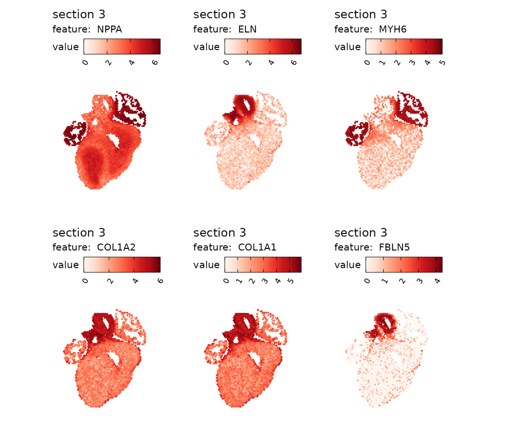

```r
section_number <- 3

positive_corr <- sp_cor[[section_number]]$gene[1:6]

MapFeatures(
  object = se,
  features = positive_corr,
  section_number = section_number,
  ncol = 3
)
```

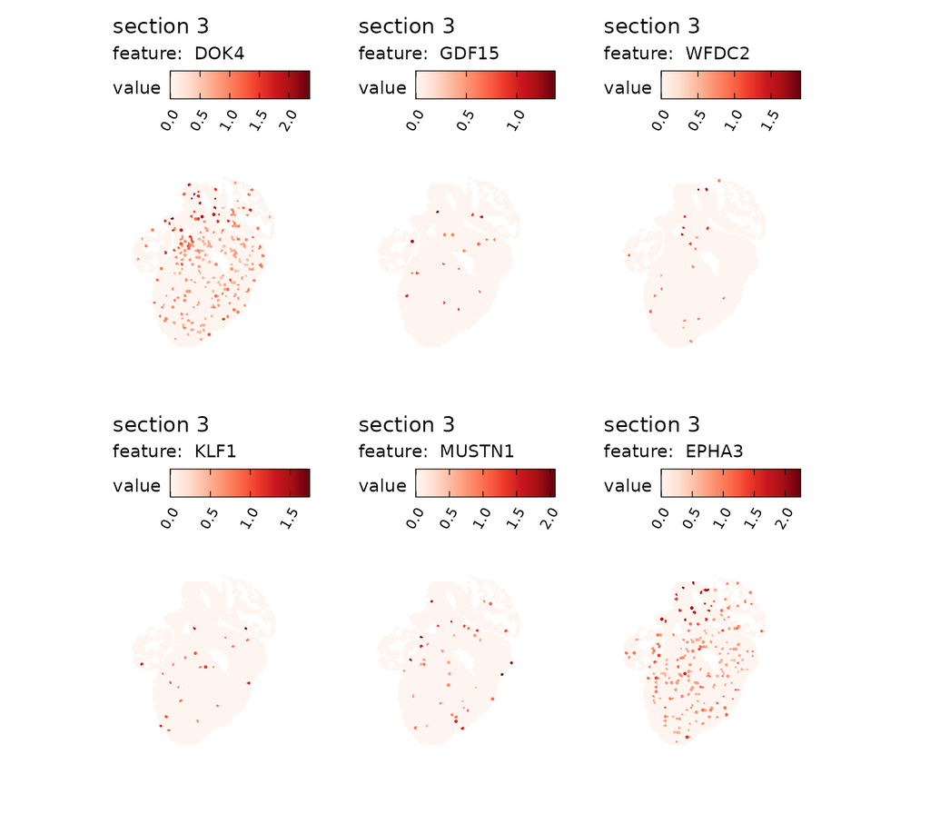

```r
negative_corr <- tail(subset(sp_cor[[section_number]], !is.nan(cor))$gene, 6)

MapFeatures(
  object = se,
  features = negative_corr,
  section_number = section_number,
  ncol = 3
)
```

### Closing note

In this workshop we went through the most important pre-processing, processing, clustering steps for a single section and for a couple of sections together. We explored some quality metrics, tried to correct for batch effect using Harmony, and explored a way to identify temporal changes across clusters of interest. Finally we understood that this is just the start, and from there much more spatially aware analyses can be performed.

Due to lack of time, we have not covered deconvolution, niche analysis, pathways, spatially aware clustering, spatial interactions, pseudotime analysis, and more.

For further explorations, here are some suggested resources:

- [semla documentation](https://spatial-research.github.io/semla/index.html)
- [Seurat spatial vignette](https://satijalab.org/seurat/articles/spatial_vignette)
- [Seurat guided clustering](https://satijalab.org/seurat/archive/v3.0/pbmc3k_tutorial.html)
- [Seurat integration & label transfer](https://satijalab.org/seurat/archive/v3.2/integration.html)
- [Single-cell QC & Clustering](https://rnabio.org/module-08-scrna/0008/02/01/QA_clustering/)
- [NBIS detailed slides](https://nbisweden.github.io/workshop-scRNAseq/home_contents.html)
- [Deconvolution with Stereoscope](https://www.nature.com/articles/s42003-020-01247-y)
- [Spatially aware clustering with BANKSY](https://github.com/prabhakarlab/Banksy)
- [Spatial interactions with SpatialDM](https://github.com/StatBiomed/SpatialDM)